# Risk Factor Analysis

## Outcome Variable

**Outcome Variable:** haz

## Predictor Variables

**Intervention Variable:** hdlvry

**Adjustment Set:**

- arm
- sex
- W_mage
- meducyrs
- W_nrooms
- brthmon
- W_parity
- impsan
- delta_W_mage
- delta_meducyrs
- delta_W_nrooms
- delta_brthmon
- delta_W_parity
- delta_impsan

## Stratifying Variables

The analysis was stratified on these variable(s):

- agecat
- studyid
- country

## Data Summary

| agecat | studyid | country | hdlvry | n_cell | n |
| --- | --- | --- | --- | --- | --- |
| Birth | ki1000108-CMC-V-BCS-2002 | INDIA | 0 | 90 | 90 |
| Birth | ki1000108-CMC-V-BCS-2002 | INDIA | 1 | 0 | 90 |
| Birth | ki1000108-IRC | INDIA | 0 | 381 | 388 |
| Birth | ki1000108-IRC | INDIA | 1 | 7 | 388 |
| Birth | ki1000109-EE | PAKISTAN | 0 | 2 | 2 |
| Birth | ki1000109-EE | PAKISTAN | 1 | 0 | 2 |
| Birth | ki1000304b-SAS-CompFeed | INDIA | 0 | 11 | 180 |
| Birth | ki1000304b-SAS-CompFeed | INDIA | 1 | 169 | 180 |
| Birth | ki1017093c-NIH-Crypto | BANGLADESH | 0 | 22 | 27 |
| Birth | ki1017093c-NIH-Crypto | BANGLADESH | 1 | 5 | 27 |
| Birth | ki1135781-COHORTS | INDIA | 0 | 2938 | 4694 |
| Birth | ki1135781-COHORTS | INDIA | 1 | 1756 | 4694 |
| Birth | kiGH5241-JiVitA-3 | BANGLADESH | 0 | 11 | 300 |
| Birth | kiGH5241-JiVitA-3 | BANGLADESH | 1 | 289 | 300 |
| Birth | kiGH5241-JiVitA-4 | BANGLADESH | 0 | 47 | 820 |
| Birth | kiGH5241-JiVitA-4 | BANGLADESH | 1 | 773 | 820 |
| 6 months | ki1000108-CMC-V-BCS-2002 | INDIA | 0 | 358 | 366 |
| 6 months | ki1000108-CMC-V-BCS-2002 | INDIA | 1 | 8 | 366 |
| 6 months | ki1000108-IRC | INDIA | 0 | 399 | 407 |
| 6 months | ki1000108-IRC | INDIA | 1 | 8 | 407 |
| 6 months | ki1000109-EE | PAKISTAN | 0 | 248 | 370 |
| 6 months | ki1000109-EE | PAKISTAN | 1 | 122 | 370 |
| 6 months | ki1000304b-SAS-CompFeed | INDIA | 0 | 147 | 1091 |
| 6 months | ki1000304b-SAS-CompFeed | INDIA | 1 | 944 | 1091 |
| 6 months | ki1000304b-SAS-FoodSuppl | INDIA | 0 | 76 | 380 |
| 6 months | ki1000304b-SAS-FoodSuppl | INDIA | 1 | 304 | 380 |
| 6 months | ki1017093b-PROVIDE | BANGLADESH | 0 | 433 | 583 |
| 6 months | ki1017093b-PROVIDE | BANGLADESH | 1 | 150 | 583 |
| 6 months | ki1017093c-NIH-Crypto | BANGLADESH | 0 | 554 | 715 |
| 6 months | ki1017093c-NIH-Crypto | BANGLADESH | 1 | 161 | 715 |
| 6 months | ki1066203-TanzaniaChild2 | TANZANIA, UNITED REPUBLIC OF | 0 | 1889 | 1921 |
| 6 months | ki1066203-TanzaniaChild2 | TANZANIA, UNITED REPUBLIC OF | 1 | 32 | 1921 |
| 6 months | ki1113344-GMS-Nepal | NEPAL | 0 | 129 | 527 |
| 6 months | ki1113344-GMS-Nepal | NEPAL | 1 | 398 | 527 |
| 6 months | ki1135781-COHORTS | INDIA | 0 | 2900 | 4699 |
| 6 months | ki1135781-COHORTS | INDIA | 1 | 1799 | 4699 |
| 6 months | kiGH5241-JiVitA-3 | BANGLADESH | 0 | 39 | 332 |
| 6 months | kiGH5241-JiVitA-3 | BANGLADESH | 1 | 293 | 332 |
| 6 months | kiGH5241-JiVitA-4 | BANGLADESH | 0 | 1081 | 4038 |
| 6 months | kiGH5241-JiVitA-4 | BANGLADESH | 1 | 2957 | 4038 |
| 24 months | ki1000108-CMC-V-BCS-2002 | INDIA | 0 | 361 | 369 |
| 24 months | ki1000108-CMC-V-BCS-2002 | INDIA | 1 | 8 | 369 |
| 24 months | ki1000108-IRC | INDIA | 0 | 401 | 409 |
| 24 months | ki1000108-IRC | INDIA | 1 | 8 | 409 |
| 24 months | ki1017093b-PROVIDE | BANGLADESH | 0 | 432 | 577 |
| 24 months | ki1017093b-PROVIDE | BANGLADESH | 1 | 145 | 577 |
| 24 months | ki1017093c-NIH-Crypto | BANGLADESH | 0 | 391 | 514 |
| 24 months | ki1017093c-NIH-Crypto | BANGLADESH | 1 | 123 | 514 |
| 24 months | ki1066203-TanzaniaChild2 | TANZANIA, UNITED REPUBLIC OF | 0 | 6 | 6 |
| 24 months | ki1066203-TanzaniaChild2 | TANZANIA, UNITED REPUBLIC OF | 1 | 0 | 6 |
| 24 months | ki1113344-GMS-Nepal | NEPAL | 0 | 120 | 467 |
| 24 months | ki1113344-GMS-Nepal | NEPAL | 1 | 347 | 467 |
| 24 months | ki1135781-COHORTS | INDIA | 0 | 2233 | 3559 |
| 24 months | ki1135781-COHORTS | INDIA | 1 | 1326 | 3559 |
| 24 months | kiGH5241-JiVitA-3 | BANGLADESH | 0 | 35 | 291 |
| 24 months | kiGH5241-JiVitA-3 | BANGLADESH | 1 | 256 | 291 |
| 24 months | kiGH5241-JiVitA-4 | BANGLADESH | 0 | 1033 | 4005 |
| 24 months | kiGH5241-JiVitA-4 | BANGLADESH | 1 | 2972 | 4005 |

The following strata were considered:

- agecat: 24 months, studyid: ki1000108-CMC-V-BCS-2002, country: INDIA
- agecat: 24 months, studyid: ki1000108-IRC, country: INDIA
- agecat: 24 months, studyid: ki1017093b-PROVIDE, country: BANGLADESH
- agecat: 24 months, studyid: ki1017093c-NIH-Crypto, country: BANGLADESH
- agecat: 24 months, studyid: ki1066203-TanzaniaChild2, country: TANZANIA, UNITED REPUBLIC OF
- agecat: 24 months, studyid: ki1113344-GMS-Nepal, country: NEPAL
- agecat: 24 months, studyid: ki1135781-COHORTS, country: INDIA
- agecat: 24 months, studyid: kiGH5241-JiVitA-3, country: BANGLADESH
- agecat: 24 months, studyid: kiGH5241-JiVitA-4, country: BANGLADESH
- agecat: 6 months, studyid: ki1000108-CMC-V-BCS-2002, country: INDIA
- agecat: 6 months, studyid: ki1000108-IRC, country: INDIA
- agecat: 6 months, studyid: ki1000109-EE, country: PAKISTAN
- agecat: 6 months, studyid: ki1000304b-SAS-CompFeed, country: INDIA
- agecat: 6 months, studyid: ki1000304b-SAS-FoodSuppl, country: INDIA
- agecat: 6 months, studyid: ki1017093b-PROVIDE, country: BANGLADESH
- agecat: 6 months, studyid: ki1017093c-NIH-Crypto, country: BANGLADESH
- agecat: 6 months, studyid: ki1066203-TanzaniaChild2, country: TANZANIA, UNITED REPUBLIC OF
- agecat: 6 months, studyid: ki1113344-GMS-Nepal, country: NEPAL
- agecat: 6 months, studyid: ki1135781-COHORTS, country: INDIA
- agecat: 6 months, studyid: kiGH5241-JiVitA-3, country: BANGLADESH
- agecat: 6 months, studyid: kiGH5241-JiVitA-4, country: BANGLADESH
- agecat: Birth, studyid: ki1000108-CMC-V-BCS-2002, country: INDIA
- agecat: Birth, studyid: ki1000108-IRC, country: INDIA
- agecat: Birth, studyid: ki1000109-EE, country: PAKISTAN
- agecat: Birth, studyid: ki1000304b-SAS-CompFeed, country: INDIA
- agecat: Birth, studyid: ki1017093c-NIH-Crypto, country: BANGLADESH
- agecat: Birth, studyid: ki1135781-COHORTS, country: INDIA
- agecat: Birth, studyid: kiGH5241-JiVitA-3, country: BANGLADESH
- agecat: Birth, studyid: kiGH5241-JiVitA-4, country: BANGLADESH

### Dropped Strata

Some strata were dropped due to rare outcomes:

- agecat: Birth, studyid: ki1000108-CMC-V-BCS-2002, country: INDIA
- agecat: Birth, studyid: ki1000109-EE, country: PAKISTAN
- agecat: 24 months, studyid: ki1066203-TanzaniaChild2, country: TANZANIA, UNITED REPUBLIC OF

## Methods Detail

We’re interested in the causal parameters $E[Y_a]$ for all values of $a \in \mathcal{A}$. These parameters represent the mean outcome if, possibly contrary to fact, we intervened to set all units to have $A=a$. Under the randomization and positivity assumptions, these are identified by the statistical parameters $\psi_a=E_W[E_{Y|A,W}(Y|A=a,W)]$. In addition, we’re interested in the mean of $Y$, $E[Y]$ under no intervention (the observed mean). We will estimate these parameters by using SuperLearner to fit the relevant likelihood factors – $E_{Y|A,W}(Y|A=a,W)$ and $p(A=a|W)$, and then updating our likelihood fit using a joint TMLE.

For unadjusted analyses ($W=\{\}$), initial likelihoods were estimated using Lrnr_glm to estimate the simple $E(Y|A)$ and Lrnr_mean to estimate $p(A)$. For adjusted analyses, a small library containing Lrnr_glmnet, Lrnr_xgboost, and Lrnr_mean was used.

Having estimated these parameters, we will then use the delta method to estimate relative risks and attributable risks relative to a prespecified baseline level of $A$.

# Results Detail

## Results Plots

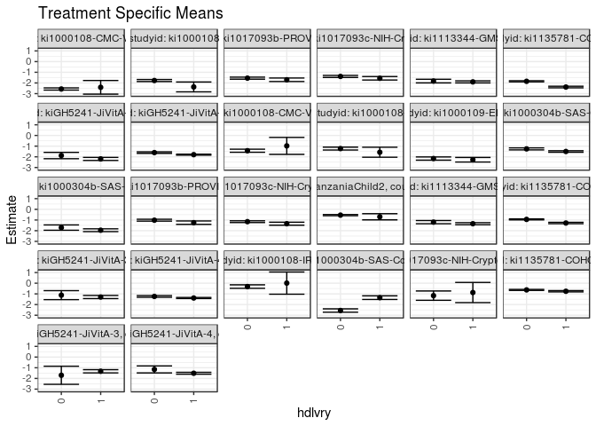

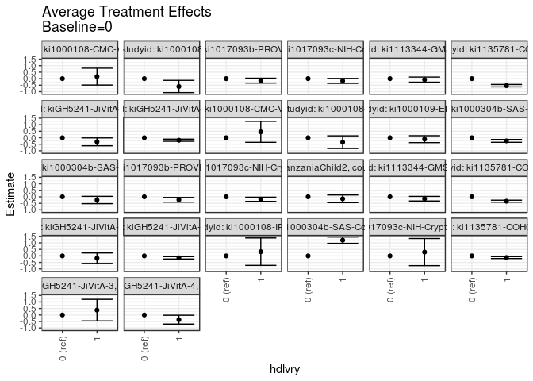

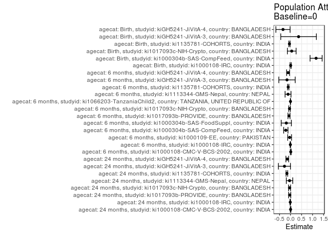

## Results Table

### Parameter: TSM

| agecat | studyid | country | intervention_level | baseline_level | estimate | ci_lower | ci_upper |
| --- | --- | --- | --- | --- | --- | --- | --- |
| Birth | ki1000108-IRC | INDIA | 0 | NA | -0.3138845 | -0.4765233 | -0.1512457 |
| Birth | ki1000108-IRC | INDIA | 1 | NA | 0.0100000 | -1.0310607 | 1.0510607 |
| Birth | ki1000304b-SAS-CompFeed | INDIA | 0 | NA | -2.5572118 | -2.7131506 | -2.4012730 |
| Birth | ki1000304b-SAS-CompFeed | INDIA | 1 | NA | -1.3531181 | -1.5244103 | -1.1818258 |
| Birth | ki1017093c-NIH-Crypto | BANGLADESH | 0 | NA | -1.1640909 | -1.6003506 | -0.7278312 |
| Birth | ki1017093c-NIH-Crypto | BANGLADESH | 1 | NA | -0.8720000 | -1.8180272 | 0.0740272 |
| Birth | ki1135781-COHORTS | INDIA | 0 | NA | -0.6271730 | -0.6719424 | -0.5824035 |
| Birth | ki1135781-COHORTS | INDIA | 1 | NA | -0.7551840 | -0.8146689 | -0.6956991 |
| Birth | kiGH5241-JiVitA-3 | BANGLADESH | 0 | NA | -1.7034528 | -2.5528177 | -0.8540879 |
| Birth | kiGH5241-JiVitA-3 | BANGLADESH | 1 | NA | -1.3298832 | -1.4803775 | -1.1793889 |
| Birth | kiGH5241-JiVitA-4 | BANGLADESH | 0 | NA | -1.1554440 | -1.4838218 | -0.8270661 |
| Birth | kiGH5241-JiVitA-4 | BANGLADESH | 1 | NA | -1.5151673 | -1.6023485 | -1.4279861 |
| 6 months | ki1000108-CMC-V-BCS-2002 | INDIA | 0 | NA | -1.4288687 | -1.5726614 | -1.2850760 |
| 6 months | ki1000108-CMC-V-BCS-2002 | INDIA | 1 | NA | -0.9754167 | -1.7693720 | -0.1814613 |
| 6 months | ki1000108-IRC | INDIA | 0 | NA | -1.2276901 | -1.3618868 | -1.0934933 |
| 6 months | ki1000108-IRC | INDIA | 1 | NA | -1.5693750 | -2.0379505 | -1.1007995 |
| 6 months | ki1000109-EE | PAKISTAN | 0 | NA | -2.1608109 | -2.3117159 | -2.0099059 |
| 6 months | ki1000109-EE | PAKISTAN | 1 | NA | -2.2726635 | -2.4883165 | -2.0570104 |
| 6 months | ki1000304b-SAS-CompFeed | INDIA | 0 | NA | -1.2564964 | -1.3503946 | -1.1625983 |
| 6 months | ki1000304b-SAS-CompFeed | INDIA | 1 | NA | -1.4987295 | -1.5699172 | -1.4275419 |
| 6 months | ki1000304b-SAS-FoodSuppl | INDIA | 0 | NA | -1.7081754 | -1.9565976 | -1.4597532 |
| 6 months | ki1000304b-SAS-FoodSuppl | INDIA | 1 | NA | -1.9549708 | -2.0859680 | -1.8239737 |
| 6 months | ki1017093b-PROVIDE | BANGLADESH | 0 | NA | -1.0173348 | -1.1054350 | -0.9292346 |
| 6 months | ki1017093b-PROVIDE | BANGLADESH | 1 | NA | -1.2478257 | -1.4057064 | -1.0899449 |
| 6 months | ki1017093c-NIH-Crypto | BANGLADESH | 0 | NA | -1.1533840 | -1.2362241 | -1.0705439 |
| 6 months | ki1017093c-NIH-Crypto | BANGLADESH | 1 | NA | -1.3455259 | -1.4833877 | -1.2076640 |
| 6 months | ki1066203-TanzaniaChild2 | TANZANIA, UNITED REPUBLIC OF | 0 | NA | -0.5418351 | -0.5931681 | -0.4905021 |
| 6 months | ki1066203-TanzaniaChild2 | TANZANIA, UNITED REPUBLIC OF | 1 | NA | -0.6975019 | -0.9864376 | -0.4085662 |
| 6 months | ki1113344-GMS-Nepal | NEPAL | 0 | NA | -1.1992421 | -1.3485978 | -1.0498863 |
| 6 months | ki1113344-GMS-Nepal | NEPAL | 1 | NA | -1.3454714 | -1.4408111 | -1.2501317 |
| 6 months | ki1135781-COHORTS | INDIA | 0 | NA | -0.9413654 | -0.9861362 | -0.8965946 |
| 6 months | ki1135781-COHORTS | INDIA | 1 | NA | -1.2803092 | -1.3437837 | -1.2168348 |
| 6 months | kiGH5241-JiVitA-3 | BANGLADESH | 0 | NA | -1.1189841 | -1.5407299 | -0.6972382 |
| 6 months | kiGH5241-JiVitA-3 | BANGLADESH | 1 | NA | -1.2940073 | -1.4402771 | -1.1477374 |
| 6 months | kiGH5241-JiVitA-4 | BANGLADESH | 0 | NA | -1.2387525 | -1.3194830 | -1.1580220 |
| 6 months | kiGH5241-JiVitA-4 | BANGLADESH | 1 | NA | -1.3859821 | -1.4353665 | -1.3365977 |
| 24 months | ki1000108-CMC-V-BCS-2002 | INDIA | 0 | NA | -2.5650139 | -2.6667807 | -2.4632470 |
| 24 months | ki1000108-CMC-V-BCS-2002 | INDIA | 1 | NA | -2.4075000 | -3.0472699 | -1.7677301 |
| 24 months | ki1000108-IRC | INDIA | 0 | NA | -1.7707024 | -1.8661096 | -1.6752952 |
| 24 months | ki1000108-IRC | INDIA | 1 | NA | -2.3727083 | -2.8339592 | -1.9114574 |
| 24 months | ki1017093b-PROVIDE | BANGLADESH | 0 | NA | -1.5485611 | -1.6452987 | -1.4518234 |
| 24 months | ki1017093b-PROVIDE | BANGLADESH | 1 | NA | -1.7006130 | -1.8627276 | -1.5384985 |
| 24 months | ki1017093c-NIH-Crypto | BANGLADESH | 0 | NA | -1.3880339 | -1.4849095 | -1.2911583 |
| 24 months | ki1017093c-NIH-Crypto | BANGLADESH | 1 | NA | -1.5617299 | -1.7236282 | -1.3998315 |
| 24 months | ki1113344-GMS-Nepal | NEPAL | 0 | NA | -1.8230095 | -1.9929763 | -1.6530428 |
| 24 months | ki1113344-GMS-Nepal | NEPAL | 1 | NA | -1.8979198 | -1.9948767 | -1.8009630 |
| 24 months | ki1135781-COHORTS | INDIA | 0 | NA | -1.8446300 | -1.8975767 | -1.7916833 |
| 24 months | ki1135781-COHORTS | INDIA | 1 | NA | -2.3828949 | -2.4575481 | -2.3082418 |
| 24 months | kiGH5241-JiVitA-3 | BANGLADESH | 0 | NA | -1.8797977 | -2.1773932 | -1.5822022 |
| 24 months | kiGH5241-JiVitA-3 | BANGLADESH | 1 | NA | -2.1962880 | -2.3374163 | -2.0551597 |
| 24 months | kiGH5241-JiVitA-4 | BANGLADESH | 0 | NA | -1.6029423 | -1.6762285 | -1.5296562 |
| 24 months | kiGH5241-JiVitA-4 | BANGLADESH | 1 | NA | -1.7966808 | -1.8409658 | -1.7523958 |

### Parameter: E(Y)

| agecat | studyid | country | intervention_level | baseline_level | estimate | ci_lower | ci_upper |
| --- | --- | --- | --- | --- | --- | --- | --- |
| Birth | ki1000108-IRC | INDIA | NA | NA | -0.3080412 | -0.4687931 | -0.1472894 |
| Birth | ki1000304b-SAS-CompFeed | INDIA | NA | NA | -1.3976667 | -1.5639119 | -1.2314214 |
| Birth | ki1017093c-NIH-Crypto | BANGLADESH | NA | NA | -1.1100000 | -1.5086894 | -0.7113106 |
| Birth | ki1135781-COHORTS | INDIA | NA | NA | -0.6762420 | -0.7093108 | -0.6431732 |
| Birth | kiGH5241-JiVitA-3 | BANGLADESH | NA | NA | -1.3381333 | -1.4898513 | -1.1864153 |
| Birth | kiGH5241-JiVitA-4 | BANGLADESH | NA | NA | -1.4966707 | -1.5808284 | -1.4125130 |
| 6 months | ki1000108-CMC-V-BCS-2002 | INDIA | NA | NA | -1.4189572 | -1.5607165 | -1.2771979 |
| 6 months | ki1000108-IRC | INDIA | NA | NA | -1.2344062 | -1.3658524 | -1.1029600 |
| 6 months | ki1000109-EE | PAKISTAN | NA | NA | -2.2011622 | -2.3246467 | -2.0776776 |
| 6 months | ki1000304b-SAS-CompFeed | INDIA | NA | NA | -1.4699588 | -1.5446559 | -1.3952616 |
| 6 months | ki1000304b-SAS-FoodSuppl | INDIA | NA | NA | -1.8986842 | -2.0118892 | -1.7854792 |
| 6 months | ki1017093b-PROVIDE | BANGLADESH | NA | NA | -1.0871041 | -1.1635539 | -1.0106543 |
| 6 months | ki1017093c-NIH-Crypto | BANGLADESH | NA | NA | -1.1986783 | -1.2700937 | -1.1272630 |
| 6 months | ki1066203-TanzaniaChild2 | TANZANIA, UNITED REPUBLIC OF | NA | NA | -0.5440573 | -0.5945614 | -0.4935533 |
| 6 months | ki1113344-GMS-Nepal | NEPAL | NA | NA | -1.3111986 | -1.3908744 | -1.2315228 |
| 6 months | ki1135781-COHORTS | INDIA | NA | NA | -1.0458076 | -1.0793244 | -1.0122908 |
| 6 months | kiGH5241-JiVitA-3 | BANGLADESH | NA | NA | -1.2787349 | -1.4248268 | -1.1326431 |
| 6 months | kiGH5241-JiVitA-4 | BANGLADESH | NA | NA | -1.3481303 | -1.3904710 | -1.3057895 |
| 24 months | ki1000108-CMC-V-BCS-2002 | INDIA | NA | NA | -2.5615989 | -2.6621298 | -2.4610681 |
| 24 months | ki1000108-IRC | INDIA | NA | NA | -1.7824776 | -1.8765600 | -1.6883952 |
| 24 months | ki1017093b-PROVIDE | BANGLADESH | NA | NA | -1.5861179 | -1.6693668 | -1.5028689 |
| 24 months | ki1017093c-NIH-Crypto | BANGLADESH | NA | NA | -1.4295331 | -1.5127726 | -1.3462935 |
| 24 months | ki1113344-GMS-Nepal | NEPAL | NA | NA | -1.8686046 | -1.9550497 | -1.7821594 |
| 24 months | ki1135781-COHORTS | INDIA | NA | NA | -2.0097359 | -2.0499675 | -1.9695043 |
| 24 months | kiGH5241-JiVitA-3 | BANGLADESH | NA | NA | -2.1549141 | -2.2975185 | -2.0123097 |
| 24 months | kiGH5241-JiVitA-4 | BANGLADESH | NA | NA | -1.7500225 | -1.7884190 | -1.7116259 |

### Parameter: ATE

| agecat | studyid | country | intervention_level | baseline_level | estimate | ci_lower | ci_upper |
| --- | --- | --- | --- | --- | --- | --- | --- |
| Birth | ki1000108-IRC | INDIA | 0 | 0 | 0.0000000 | 0.0000000 | 0.0000000 |
| Birth | ki1000108-IRC | INDIA | 1 | 0 | 0.3238845 | -0.7298036 | 1.3775727 |
| Birth | ki1000304b-SAS-CompFeed | INDIA | 0 | 0 | 0.0000000 | 0.0000000 | 0.0000000 |
| Birth | ki1000304b-SAS-CompFeed | INDIA | 1 | 0 | 1.2040937 | 0.9614163 | 1.4467711 |
| Birth | ki1017093c-NIH-Crypto | BANGLADESH | 0 | 0 | 0.0000000 | 0.0000000 | 0.0000000 |
| Birth | ki1017093c-NIH-Crypto | BANGLADESH | 1 | 0 | 0.2920909 | -0.7496816 | 1.3338634 |
| Birth | ki1135781-COHORTS | INDIA | 0 | 0 | 0.0000000 | 0.0000000 | 0.0000000 |
| Birth | ki1135781-COHORTS | INDIA | 1 | 0 | -0.1280110 | -0.2022073 | -0.0538147 |
| Birth | kiGH5241-JiVitA-3 | BANGLADESH | 0 | 0 | 0.0000000 | 0.0000000 | 0.0000000 |
| Birth | kiGH5241-JiVitA-3 | BANGLADESH | 1 | 0 | 0.3735696 | -0.4533324 | 1.2004715 |
| Birth | kiGH5241-JiVitA-4 | BANGLADESH | 0 | 0 | 0.0000000 | 0.0000000 | 0.0000000 |
| Birth | kiGH5241-JiVitA-4 | BANGLADESH | 1 | 0 | -0.3597233 | -0.6994371 | -0.0200096 |
| 6 months | ki1000108-CMC-V-BCS-2002 | INDIA | 0 | 0 | 0.0000000 | 0.0000000 | 0.0000000 |
| 6 months | ki1000108-CMC-V-BCS-2002 | INDIA | 1 | 0 | 0.4534520 | -0.3534193 | 1.2603234 |
| 6 months | ki1000108-IRC | INDIA | 0 | 0 | 0.0000000 | 0.0000000 | 0.0000000 |
| 6 months | ki1000108-IRC | INDIA | 1 | 0 | -0.3416849 | -0.8290982 | 0.1457284 |
| 6 months | ki1000109-EE | PAKISTAN | 0 | 0 | 0.0000000 | 0.0000000 | 0.0000000 |
| 6 months | ki1000109-EE | PAKISTAN | 1 | 0 | -0.1118526 | -0.3771835 | 0.1534784 |
| 6 months | ki1000304b-SAS-CompFeed | INDIA | 0 | 0 | 0.0000000 | 0.0000000 | 0.0000000 |
| 6 months | ki1000304b-SAS-CompFeed | INDIA | 1 | 0 | -0.2422331 | -0.3513840 | -0.1330823 |
| 6 months | ki1000304b-SAS-FoodSuppl | INDIA | 0 | 0 | 0.0000000 | 0.0000000 | 0.0000000 |
| 6 months | ki1000304b-SAS-FoodSuppl | INDIA | 1 | 0 | -0.2467955 | -0.5281579 | 0.0345670 |
| 6 months | ki1017093b-PROVIDE | BANGLADESH | 0 | 0 | 0.0000000 | 0.0000000 | 0.0000000 |
| 6 months | ki1017093b-PROVIDE | BANGLADESH | 1 | 0 | -0.2304909 | -0.4115071 | -0.0494746 |
| 6 months | ki1017093c-NIH-Crypto | BANGLADESH | 0 | 0 | 0.0000000 | 0.0000000 | 0.0000000 |
| 6 months | ki1017093c-NIH-Crypto | BANGLADESH | 1 | 0 | -0.1921418 | -0.3530735 | -0.0312101 |
| 6 months | ki1066203-TanzaniaChild2 | TANZANIA, UNITED REPUBLIC OF | 0 | 0 | 0.0000000 | 0.0000000 | 0.0000000 |
| 6 months | ki1066203-TanzaniaChild2 | TANZANIA, UNITED REPUBLIC OF | 1 | 0 | -0.1556668 | -0.4492270 | 0.1378934 |
| 6 months | ki1113344-GMS-Nepal | NEPAL | 0 | 0 | 0.0000000 | 0.0000000 | 0.0000000 |
| 6 months | ki1113344-GMS-Nepal | NEPAL | 1 | 0 | -0.1462293 | -0.3238341 | 0.0313755 |
| 6 months | ki1135781-COHORTS | INDIA | 0 | 0 | 0.0000000 | 0.0000000 | 0.0000000 |
| 6 months | ki1135781-COHORTS | INDIA | 1 | 0 | -0.3389438 | -0.4162901 | -0.2615976 |
| 6 months | kiGH5241-JiVitA-3 | BANGLADESH | 0 | 0 | 0.0000000 | 0.0000000 | 0.0000000 |
| 6 months | kiGH5241-JiVitA-3 | BANGLADESH | 1 | 0 | -0.1750232 | -0.5766775 | 0.2266311 |
| 6 months | kiGH5241-JiVitA-4 | BANGLADESH | 0 | 0 | 0.0000000 | 0.0000000 | 0.0000000 |
| 6 months | kiGH5241-JiVitA-4 | BANGLADESH | 1 | 0 | -0.1472296 | -0.2387273 | -0.0557320 |
| 24 months | ki1000108-CMC-V-BCS-2002 | INDIA | 0 | 0 | 0.0000000 | 0.0000000 | 0.0000000 |
| 24 months | ki1000108-CMC-V-BCS-2002 | INDIA | 1 | 0 | 0.1575139 | -0.4902994 | 0.8053271 |
| 24 months | ki1000108-IRC | INDIA | 0 | 0 | 0.0000000 | 0.0000000 | 0.0000000 |
| 24 months | ki1000108-IRC | INDIA | 1 | 0 | -0.6020059 | -1.0730207 | -0.1309911 |
| 24 months | ki1017093b-PROVIDE | BANGLADESH | 0 | 0 | 0.0000000 | 0.0000000 | 0.0000000 |
| 24 months | ki1017093b-PROVIDE | BANGLADESH | 1 | 0 | -0.1520520 | -0.3407201 | 0.0366162 |
| 24 months | ki1017093c-NIH-Crypto | BANGLADESH | 0 | 0 | 0.0000000 | 0.0000000 | 0.0000000 |
| 24 months | ki1017093c-NIH-Crypto | BANGLADESH | 1 | 0 | -0.1736960 | -0.3626258 | 0.0152338 |
| 24 months | ki1113344-GMS-Nepal | NEPAL | 0 | 0 | 0.0000000 | 0.0000000 | 0.0000000 |
| 24 months | ki1113344-GMS-Nepal | NEPAL | 1 | 0 | -0.0749103 | -0.2702901 | 0.1204695 |
| 24 months | ki1135781-COHORTS | INDIA | 0 | 0 | 0.0000000 | 0.0000000 | 0.0000000 |
| 24 months | ki1135781-COHORTS | INDIA | 1 | 0 | -0.5382649 | -0.6307269 | -0.4458030 |
| 24 months | kiGH5241-JiVitA-3 | BANGLADESH | 0 | 0 | 0.0000000 | 0.0000000 | 0.0000000 |
| 24 months | kiGH5241-JiVitA-3 | BANGLADESH | 1 | 0 | -0.3164903 | -0.6182396 | -0.0147410 |
| 24 months | kiGH5241-JiVitA-4 | BANGLADESH | 0 | 0 | 0.0000000 | 0.0000000 | 0.0000000 |
| 24 months | kiGH5241-JiVitA-4 | BANGLADESH | 1 | 0 | -0.1937385 | -0.2766936 | -0.1107833 |

### Parameter: PAR

| agecat | studyid | country | intervention_level | baseline_level | estimate | ci_lower | ci_upper |
| --- | --- | --- | --- | --- | --- | --- | --- |
| Birth | ki1000108-IRC | INDIA | 0 | NA | 0.0058433 | -0.0208468 | 0.0325333 |
| Birth | ki1000304b-SAS-CompFeed | INDIA | 0 | NA | 1.1595451 | 0.8870100 | 1.4320802 |
| Birth | ki1017093c-NIH-Crypto | BANGLADESH | 0 | NA | 0.0540909 | -0.1436981 | 0.2518800 |
| Birth | ki1135781-COHORTS | INDIA | 0 | NA | -0.0490690 | -0.0777048 | -0.0204332 |
| Birth | kiGH5241-JiVitA-3 | BANGLADESH | 0 | NA | 0.3653194 | -0.4410021 | 1.1716410 |
| Birth | kiGH5241-JiVitA-4 | BANGLADESH | 0 | NA | -0.3412267 | -0.6629131 | -0.0195404 |
| 6 months | ki1000108-CMC-V-BCS-2002 | INDIA | 0 | NA | 0.0099115 | -0.0113762 | 0.0311993 |
| 6 months | ki1000108-IRC | INDIA | 0 | NA | -0.0067162 | -0.0197457 | 0.0063134 |
| 6 months | ki1000109-EE | PAKISTAN | 0 | NA | -0.0403513 | -0.1290258 | 0.0483233 |
| 6 months | ki1000304b-SAS-CompFeed | INDIA | 0 | NA | -0.2134623 | -0.3110857 | -0.1158389 |
| 6 months | ki1000304b-SAS-FoodSuppl | INDIA | 0 | NA | -0.1905088 | -0.4216201 | 0.0406024 |
| 6 months | ki1017093b-PROVIDE | BANGLADESH | 0 | NA | -0.0697692 | -0.1161312 | -0.0234073 |
| 6 months | ki1017093c-NIH-Crypto | BANGLADESH | 0 | NA | -0.0452943 | -0.0819637 | -0.0086249 |
| 6 months | ki1066203-TanzaniaChild2 | TANZANIA, UNITED REPUBLIC OF | 0 | NA | -0.0022222 | -0.0092490 | 0.0048045 |
| 6 months | ki1113344-GMS-Nepal | NEPAL | 0 | NA | -0.1119565 | -0.2469417 | 0.0230287 |
| 6 months | ki1135781-COHORTS | INDIA | 0 | NA | -0.1044422 | -0.1344735 | -0.0744110 |
| 6 months | kiGH5241-JiVitA-3 | BANGLADESH | 0 | NA | -0.1597509 | -0.5297195 | 0.2102178 |
| 6 months | kiGH5241-JiVitA-4 | BANGLADESH | 0 | NA | -0.1093778 | -0.1761726 | -0.0425830 |
| 24 months | ki1000108-CMC-V-BCS-2002 | INDIA | 0 | NA | 0.0034149 | -0.0129491 | 0.0197790 |
| 24 months | ki1000108-IRC | INDIA | 0 | NA | -0.0117752 | -0.0260614 | 0.0025111 |
| 24 months | ki1017093b-PROVIDE | BANGLADESH | 0 | NA | -0.0375568 | -0.0851167 | 0.0100031 |
| 24 months | ki1017093c-NIH-Crypto | BANGLADESH | 0 | NA | -0.0414992 | -0.0871420 | 0.0041437 |
| 24 months | ki1113344-GMS-Nepal | NEPAL | 0 | NA | -0.0455950 | -0.1907859 | 0.0995958 |
| 24 months | ki1135781-COHORTS | INDIA | 0 | NA | -0.1651059 | -0.2020555 | -0.1281562 |
| 24 months | kiGH5241-JiVitA-3 | BANGLADESH | 0 | NA | -0.2751164 | -0.5504601 | 0.0002273 |
| 24 months | kiGH5241-JiVitA-4 | BANGLADESH | 0 | NA | -0.1470801 | -0.2094757 | -0.0846845 |